# Statistical inference with the GSS data

## Setup

### Load packages

```r
library(ggplot2)
library(dplyr)
library(statsr)
```

## Load data

### Introduction

The GSS gathers data on contemporary American society in order to monitor and explain trends and constants in attitudes, behaviors, and attributes. Hundreds of trends have been tracked since 1972. The GSS contains a standard core of demographic, behavioral, and attitudinal questions, plus topics of special interest. Among the topics covered are civil liberties, crime and violence, intergroup tolerance, morality, national spending priorities, psychological well-being, social mobility, and stress and traumatic events. Altogether the GSS is the single best source for sociological and attitudinal trend data covering the United States

(Source : http://gss.norc.org/About-The-GSS)

```r
load("gss.Rdata")
```

## Part 1: Data

The target population of the GSS is adults (18+) living in households in the United States. The GSS sample is drawn using an area probability design which could be clustered or multistage sampling. Respondents come from urban, suburban and rural geographic areas. The GSS randomly selects respondents in households accross the US to to take part in the survey (which indicates that the sampling method is probably multistage sampling). Participation is strictly voluntary. What this tells us is that :-

- The sample for GSS is a random sample
- The individual respondents can be assumed to be independent of one another
- Any conclusion drawn from this sample can be generalised to the US population at large
- A correlation/association between two variables cannot be deemed causal as the study is observational and not experimental

Bias - Since this is a survey and not a poll, voluntary response bias is not much of a concern. However, since the questions cover a diverse range of issues including national spending priorities, marijuana use, crime and punishment, race relations, quality of life, confidence in institutions, and sexual behavior - the respondent may not be completely honest with his answers due to the fear of being judged. Caution must be exercised while drawing inference.

```r
head(gss[,1:10]) #taking a look at the first 10 columns
```

```
##   caseid year age    sex  race hispanic uscitzn educ paeduc maeduc
## 1      1 1972  23 Female White     <NA>    <NA>   16     10     NA
## 2      2 1972  70   Male White     <NA>    <NA>   10      8      8
## 3      3 1972  48 Female White     <NA>    <NA>   12      8      8
## 4      4 1972  27 Female White     <NA>    <NA>   17     16     12
## 5      5 1972  61 Female White     <NA>    <NA>   12      8      8
## 6      6 1972  26   Male White     <NA>    <NA>   14     18     19
```

## Part 2: Research question

The research question - How do people with different levels of job satisfaction respond to the question - “If you were to get enough money to live as comfortably as you would like for the rest of your life, would you continue to work or would you stop working?”?

The variables of interest are - ‘satjob’ and ‘richwork’

The question is of interest to me as I would like to see if dissatisfied people are willing to work further or would they want to get enough money in order to live comfortably. Although we cannot answer the broader question - “Do people get a sense of fulfillment by doing their job or do they do it only for money and to pay their bills?” since this is an observational study, however any associations would be nice to observe.

## Part 3: Exploratory data analysis

```r
#Since there are a lot of null values in the data, let's ignore them
satjob_richwork = na.omit(gss[,c('satjob', 'richwork')])
summary(satjob_richwork)
```

```
##                satjob                  richwork
##  Very Satisfied   :10245   Continue Working:15293
##  Mod. Satisfied   : 8538   Stop Working    : 6531
##  A Little Dissat  : 2163
##  Very Dissatisfied:  878
```

satjob has 4 levels - ‘Very Satisfied’, ‘Mod. Satisfied’, ‘A Little Dissat’ and ‘Very Dissatisfied’. These are the 4 responses to the question - “On the whole, how satisfied are you with the work you do?”

richwork has 2 levels - ‘Continue Working’ and ‘Stop Working’. These are the 2 responses to the question - “If you were to get enough money to live as comfortably as you would like for the rest of your life, would you continue to work or would you stop working?”

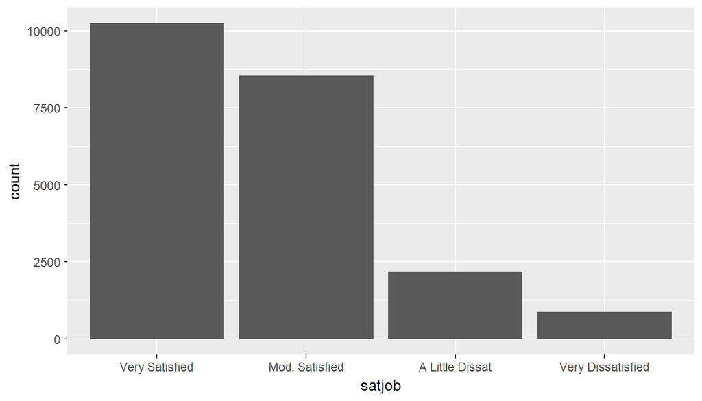

```r
#A histogram of the variable satjob
ggplot(data = satjob_richwork, aes(x=satjob)) + geom_bar()
```

Most people who responded to the question were very satisified with their job. The count drops as we go from ‘very satisfied’ to ‘very dissatisfied’

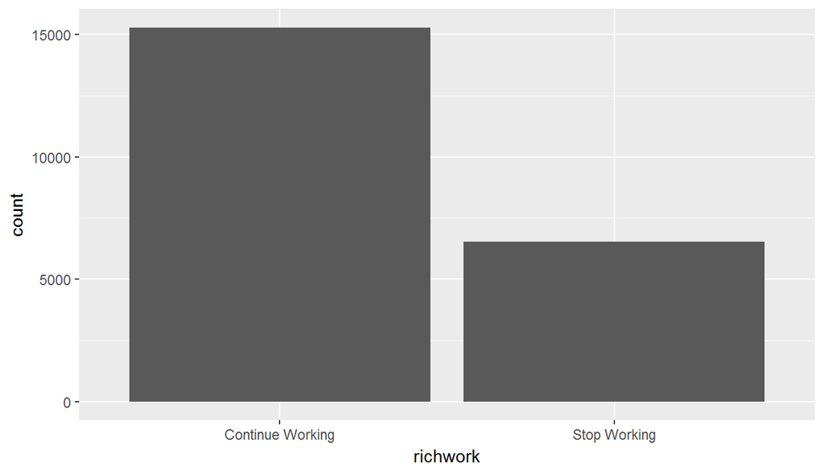

```r
#A histogram of the variable richwork
ggplot(data = satjob_richwork, aes(x=richwork)) + geom_bar()
```

The level ‘Continue Working’ is an overwhelming majority here. This means that most people would choose to continue to work even if they were offered enough money to live a comfortable life.

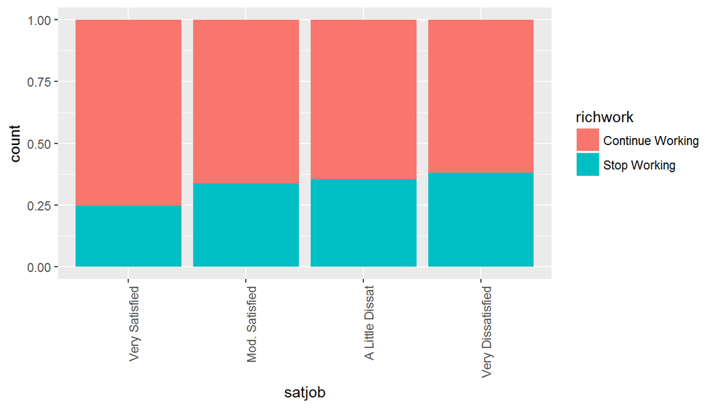

```r
#Relative proportions of 'richwork' vs normalised count of 'satjob'
ggplot(data = satjob_richwork, aes(x=satjob)) + geom_bar(aes(fill=richwork), position = 'fill') +  theme(axis.text.x = element_text(angle = 90, hjust = 1))
```

As we can see, the proportion of people who would stop working increase with increasing levels of dissatisfaction. Does this mean that the two variables are dependent or is the observed effect simply due to chance?

```r
#A numerical summary of the above plot
table(satjob_richwork$satjob, satjob_richwork$richwork)/rowSums(table(satjob_richwork$satjob, satjob_richwork$richwork))
```

```
##
##                     Continue Working Stop Working
##   Very Satisfied           0.7523670    0.2476330
##   Mod. Satisfied           0.6613961    0.3386039
##   A Little Dissat          0.6444753    0.3555247
##   Very Dissatisfied        0.6195900    0.3804100
```

By dividing by the rowsums in order to normalize the ‘satjob’ counts, we can see that the number of people who would continue to work decreases with increasing levels of dissatisfaction

## Part 4: Inference

#### The Hypotheses

The null hypothesis H0 - ‘satjob’ and ‘richwork’ are independent and the difference in proportions of people who would ‘Continue Working’ between the 4 different groups is simply due to chance.

The alternate hypothesis HA - ‘satjob’ and ‘richwork’ are dependent and there is a significant difference between the proportions of people who would ‘Continue Working’ between the 4 different groups

We’ll evaluate the hypotheses at a 5% significance level.

#### Conditions

```r
#The 2-way table for the chi-square test of independence, which is the observed distribution
two_way_observed = table(satjob_richwork$richwork, satjob_richwork$satjob)
two_way_observed
```

```
##
##                    Very Satisfied Mod. Satisfied A Little Dissat
##   Continue Working           7708           5647            1394
##   Stop Working               2537           2891             769
##
##                    Very Dissatisfied
##   Continue Working               544
##   Stop Working                   334
```

Since the variables of interest here are 2 categorical variables where ‘satjob’ has more than 2 levels, we have to use the CHI-SQUARE Test of Independence to calculate a p-value. In order to use the framework for hypothesis testing in this setup, we must first verify the conditions:-

1. Independence:
- As stated above, the GSS uses a random sample.
- We have a total of 21824 observations, which is certainly lesser than 10% of the American population.
- Each case contributes to one cell in the table. The respondent can only give one answer each for the two questions. Thus each case is independent of all other cases in the table.
2. Sample Size:
- As is evident from the above table, each particular scenario (i.e cell) has atleast 5 expected cases

Thus the conditions for the Chi-Square test of Independence are satisfied and we can go ahead with our analysis

#### Method Used & Calculations

The Chi-Square test of Independence is called an independence test since we’re evaluating the relationship between 2 categorical variables where atleast one variable has more than 2 levels. The two-way table above describes counts for combinations of outcomes for two variables. In order to test for independence, we must first calculate the expected counts. The formula for expected counts is -> (Row Total * Col Total)/(Table Total)

```r
#To calculate the row total of two_way_observed
row_total = rowSums(two_way_observed)
row_total
```

```
## Continue Working     Stop Working
##            15293             6531
```

```r
#To calculate the column total of two_way_observed
col_total = colSums(two_way_observed)
col_total
```

```
##    Very Satisfied    Mod. Satisfied   A Little Dissat Very Dissatisfied
##             10245              8538              2163               878
```

```r
#To calculate the table total of two_way_observed
table_total = sum(two_way_observed)
table_total
```

```
## [1] 21824
```

```r
#To calculate the column proportions
col_prop = col_total/table_total
col_prop
```

```
##    Very Satisfied    Mod. Satisfied   A Little Dissat Very Dissatisfied
##        0.46943732        0.39122067        0.09911107        0.04023094
```

For example, the col total for the variable ‘Very Satisfied’ is 10245, which means that 10245/21824 or 46.94% respondents are very satisfied with their job. Thus, out of 15293 respondents who would continue working, we would expect 46.94% of these respondents to be the ones who are very satisfied with their job. The expected count for (Continue Working and Very Satisfied), then becomes 7179.1049. In a similar fashion, the expected counts for every other cell can be calculated and the result is shown below

```r
#Expected counts for Continue Working
row_total[1]*col_prop
```

```
##    Very Satisfied    Mod. Satisfied   A Little Dissat Very Dissatisfied
##         7179.1049         5982.9378         1515.7056          615.2517
```

```r
#Expected counts for Stop Working
row_total[2]*col_prop
```

```
##    Very Satisfied    Mod. Satisfied   A Little Dissat Very Dissatisfied
##         3065.8951         2555.0622          647.2944          262.7483
```

```r
#The expected distribution
two_way_expected = rbind(row_total[1]*col_prop, row_total[2]*col_prop)
two_way_expected
```

```
##      Very Satisfied Mod. Satisfied A Little Dissat Very Dissatisfied
## [1,]       7179.105       5982.938       1515.7056          615.2517
## [2,]       3065.895       2555.062        647.2944          262.7483
```

Given this distribution, our job then is to see, how different the expected counts are from the observed counts. The statsitic that does this for us is the Chi-Square statistic which takes the form

chi_sq = ((observed count - expected count)^2)/(expected count) summed over all cells

The numerator is squared to standardize the difference between the observed and expected counts by making it positive and any unusual difference between the two will appear magnified or even more unusual.

```r
#To calculate the chi-square statistic
chi_sq_stat = sum(((two_way_observed - two_way_expected)^2)/(two_way_expected))
chi_sq_stat
```

```
## [1] 253.4647
```

In order to quantify how different this value is from the null and thus calculate the p-value, we also need to calculate the degrees of freedom, which is equal to (number of rows - 1) * (number of columns - 1)

```r
#To calculate the degrees of freedom
df = (nrow(two_way_observed) - 1)*(ncol(two_way_observed) - 1)
df
```

```
## [1] 3
```

Now, we can finally calculate the p-value using the pchisq() function

```r
#To calculate the p-value
pchisq(chi_sq_stat, df, lower.tail = FALSE)
```

```
## [1] 1.165322e-54
```

Which is really really small and can be assumed to be 0. The p-value is lesser than the chosen significance level of 0.05 and this provides us strong evidence that the variables ‘satjob’ and ‘richwork’ are dependent and we thus reject the null hypothesis in favor of the alternative.

```r
#A summary of the above calculations
inference(y = richwork, x = satjob, data=satjob_richwork, type='ht', statistic='proportion', method='theoretical', alternative = 'greater')
```

```
## Response variable: categorical (2 levels)
## Explanatory variable: categorical (4 levels)
## Observed:
##                    y
## x                   Continue Working Stop Working
##   Very Satisfied                7708         2537
##   Mod. Satisfied                5647         2891
##   A Little Dissat               1394          769
##   Very Dissatisfied              544          334
##
## Expected:
##                    y
## x                   Continue Working Stop Working
##   Very Satisfied           7179.1049    3065.8951
##   Mod. Satisfied           5982.9378    2555.0622
##   A Little Dissat          1515.7056     647.2944
##   Very Dissatisfied         615.2517     262.7483
##
## H0: satjob and richwork are independent
## HA: satjob and richwork are dependent
## chi_sq = 253.4647, df = 3, p_value = 0
```

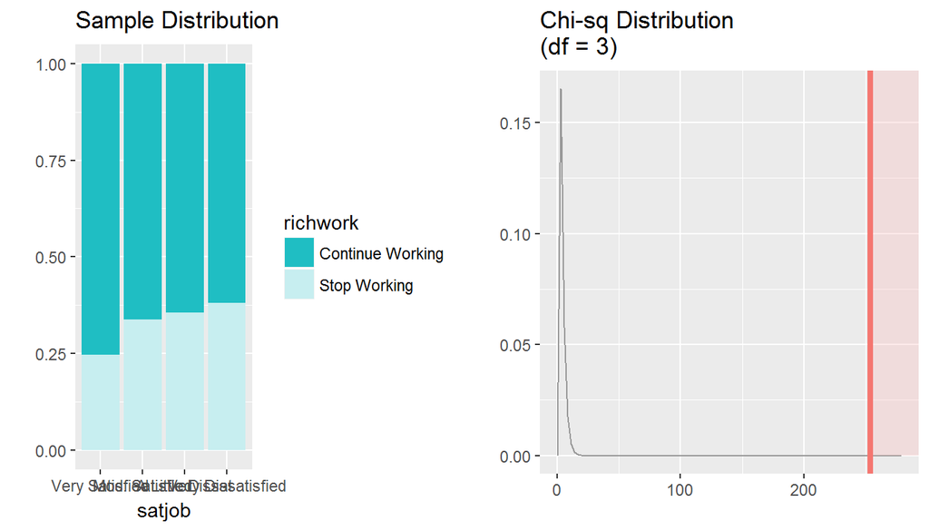

#### Interpretation and Conclusion

The p-value is a conditional probability. In this context what it means is that, if in fact ‘satjob’ and ‘richwork’ were indepedent, what is the probability of observing the distribution that we did between the two variables in the table ‘two_way_observation’. The Chi-Square statistic is so high, that the p-value is almost 0. The Chi-Square statistic is shown in red in the above plot. We can see that the distribution has a natural left boundary at 0 since chi-square statistic by its very definition has to be a positive value. Thus the distribution is positive and right skewed. The mean of the Chi-Square distribution is its degrees of freedom, which in this case is 3. As the degrees of freedom increase, the Chi-Square curve starts approaching a normal distribution. Since there is sufficient evidence of a dependence between the two variables at a significance level of 0.05, we reject the null hypothesis in favor of the alternative hypothesis

#### Reasons for not including Confidence Interval

By using the Chi-Square test of Independence, we are comparing proportions across several groups. Had we compared two groups only, then this would be case of inference on proportions and we would have a confidence interval in that case. There is no defined parameter of interest when several groups are being compared, which is what we need in order to calculate a confidence interval and thus it is not applicable in this context.